# Predicting Bad Loans

The Federal National Mortgage Association (FNMA), commonly known as Fannie Mae, is a United States government-sponsored enterprise (GSE) and, since 1968, a publicly traded company. Founded in 1938 during the Great Depression as part of the New Deal,the corporation's purpose is to expand the secondary mortgage market by securitizing mortgages in the form of mortgage-backed securities (MBS),allowing lenders to reinvest their assets into more lending and in effect increasing the number of lenders in the mortgage market by reducing the reliance on locally based savings and loan associations (or "thrifts").Its brother organization is the Federal Home Loan Mortgage Corporation (FHLMC), better known as Freddie Mac.

On January 26, 2018, Fannie Mae updated its Single-Family Loan Performance credit [dataset](http://www.fanniemae.com/portal/funding-the-market/data/loan-performance-data.html) to:

Primary dataset: • Include acquisition data for Q4 2016 and performance data through Q3 2017. • Update acquisitions files to reflect any data corrections.

HARP dataset: • Include performance data through Q3 2017.

I am goimng to use 2008Q3 data to predict which borrowers are most at risk of defaulting on their mortgage loans.

### Import the libraries

```python
from sklearn.ensemble import RandomForestClassifier, RandomForestRegressor
from sklearn.model_selection import train_test_split
from sklearn.metrics import classification_report
from sklearn.metrics import confusion_matrix
from sklearn.metrics import roc_auc_score
from sklearn.metrics import roc_curve


import pandas as pd
import pandas_profiling
import numpy as np

import matplotlib.pyplot as mp
%matplotlib inline
import seaborn as sns
```

## Read the data

```python
# column names
cols_acq = ['LOAN_ID', 'ORIGINATION_CHANNEL', 'SELLER_NAME', 'ORIG_INTEREST_RATE', 'ORIG_UNPAID_PRINCIPAL_BALANCE', 'ORIG_LOAN_TERM', 'ORIGINATION_DATE',
            'FIRST_PAYMENT_DATE', 'ORIG_LTV', 'ORIG_COMBINED_LTV', 'NUM_OF_BORROWERS', 'DEBT_TO_INCOME_RATIO', 'BORROWER_CREDIT_SCORE',
            'FIRST_TIME_HOME_BUYER_FLAG', 'LOAN_PURPOSE', 'PROPERTY_TYPE', 'NUM_OF_UNITS', 'OCCUPANCY_STATUS', 'PROPERTY_STATE', 'ZIP3',
            'MORTGAGE_INSURANCE_PCT', 'PRODUCT_TYPE', 'CO_BORROWER_CREDIT_SCORE', 'MORTGAGE_INSURANCE_TYPE', 'RELOCATION_MORTGAGE_FLAG']
# define data parser https://stackoverflow.com/questions/17465045/can-pandas-automatically-recognize-dates
dateparse = lambda x: pd.datetime.strptime(x, '%m/%Y')
# read the data
df_acq = pd.read_csv("2008Q3/Acquisition_2008Q3.txt", sep="|", names=cols_acq,
                     parse_dates=['ORIGINATION_DATE','FIRST_PAYMENT_DATE'],
                     date_parser=dateparse
                    )
```

```python
# performance column names
cols_perf = ['LOAN_ID', 'MONTHLY_REPORTING_PERIOD', 'SERVICER_NAME', 'CURRENT_INTEREST_RATE', 'CURRENT_ACTUAL_UNPAID_PRINCIPAL_BALANCE', 'LOAN_AGE',
              'REMAINING_MONTHS_TO_LEGAL_MATURITY', 'ADJUSTED_REMAINING_MONTHS_TO_MATURITY', 'MATURITY_DATE', 'METROPOLITAN_STATISTICAL_AREA',
              'CURRENT_LOAN_DELINQUENCY_STATUS', 'MODIFICATION_FLAG', 'ZERO_BALANCE_CODE', 'ZERO_BALANCE_EFFECTIVE_DATE', 'LAST_PAID_INSTALLMENT_DATE',
              'FORECLOSURE_DATE','DISPOSITION_DATE', 'FORECLOSURE_COSTS', 'PROPERTY_PRESERVATION_AND_REPAIR_COSTS', 'ASSET_RECOVERY_COSTS',
              'MISC_HOLDING_EXPENSES_AND_CREDITS', 'ASSOCIATED_TAXES_FOR_HOLDING_PROPERTY', 'NET_SALE_PROCEEDS', 'CREDIT_ENHANCEMENT_PROCEEDS',
              'REPURCHASE_MAKE_WHOLE_PROCEEDS', 'OTHER_FORECLOSURE_PROCEEDS', 'NON_INTEREST_BEARING_UPB', 'PRINCIPAL_FORGIVENESS_UPB',
              'REPURCHASE_MAKE_WHOLE_PROCEEDS_FLAG', 'FORECLOSURE_PRINCIPAL_WRITE_OFF_AMOUNT','SERVICING_ACTIVITY_FLAG']
# raed the data
df_perf = pd.read_csv("2008Q3/Performance_2008Q3.txt", sep="|", names=cols_perf, usecols=[0,15])
```

In the performance data, we are really only interested in the LoanID and ForeclosureDate columns, as this will give us the borrower identifiaction number and whether or not they ended up defaulting. After reading in the two datasets, we can perform an inner join on the acquisition and performance dataframes using the LoanID column. The resulting dataframe, df, will contain the ForeclosureDate column, and will be our target variable. For clarity, we will also rename this column as Default.

```python
# only keep the last entry for a given loan
df_perf.drop_duplicates(subset='LOAN_ID', keep='last', inplace=True)
```

```python
df = pd.merge(df_acq, df_perf, on='LOAN_ID', how='inner')
```

```python
#clear other dataframe from memory
del df_acq, df_perf
```

## Define target variable

We introduce a traget variable called `BAD_LOAN` which indicated if the borrower has defaulted.

For this we will use the `FORECLOSURE_DATE` column.

Set `BAD_LOAN = 0` when `FORECLOSURE_DATE` value is `NaN` else to `1`

```python
# indicate rows for active loans
df['FORECLOSURE_DATE'].fillna(0, inplace=True)

# indicate rows for defaulted loans
df.loc[df['FORECLOSURE_DATE'] != 0, 'FORECLOSURE_DATE'] = 1

# rename column to a meaningfull name
df.rename(index=str, columns={"FORECLOSURE_DATE": 'BAD_LOAN'}, inplace=True)
```

## Explore the data

Overview

Dataset info

| Number of variables | 27 |
| --- | --- |
| Number of observations | 353277 |
| Total Missing (%) | 8.1% |
| Total size in memory | 72.8 MiB |
| Average record size in memory | 216.0 B |

Variables types

| Numeric | 13 |
| --- | --- |
| Categorical | 8 |
| Boolean | 1 |
| Date | 2 |
| Text (Unique) | 1 |
| Rejected | 2 |
| Unsupported | 0 |

Warnings

- `CO_BORROWER_CREDIT_SCORE` has 208664 / 59.1% missing values Missing

- `DEBT_TO_INCOME_RATIO` has 11339 / 3.2% missing values Missing

- `MORTGAGE_INSURANCE_PCT` has 277888 / 78.7% missing values Missing

- `MORTGAGE_INSURANCE_TYPE` has 277888 / 78.7% missing values Missing

- `ORIG_COMBINED_LTV` is highly correlated with `ORIG_LTV` (ρ = 0.96684) Rejected

- `PRODUCT_TYPE` has constant value FRM Rejected

- `PROPERTY_STATE` has a high cardinality: 54 distinct values Warning

Variables

BAD_LOAN  
Boolean

| Distinct count | 2 |
| --- | --- |
| Unique (%) | 0.0% |
| Missing (%) | 0.0% |
| Missing (n) | 0 |

| Mean | 0.042796 |
| --- | --- |

| 0 | 338158 |
| --- | --- |
| 1 | 15119 |

Toggle details

| Value | Count | Frequency (%) |  |
| --- | --- | --- | --- |
| 0 | 338158 | 95.7% |  |
| 1 | 15119 | 4.3% |  |

BORROWER_CREDIT_SCORE  
Numeric

| Distinct count | 370 |
| --- | --- |
| Unique (%) | 0.1% |
| Missing (%) | 0.1% |
| Missing (n) | 489 |
| Infinite (%) | 0.0% |
| Infinite (n) | 0 |

| Mean | 741.07 |
| --- | --- |
| Minimum | 360 |
| Maximum | 843 |
| Zeros (%) | 0.0% |

Toggle details

**Statistics**

Quantile statistics

| Minimum | 360 |
| --- | --- |
| 5-th percentile | 641 |
| Q1 | 705 |
| Median | 752 |
| Q3 | 785 |
| 95-th percentile | 808 |
| Maximum | 843 |
| Range | 483 |
| Interquartile range | 80 |

Descriptive statistics

| Standard deviation | 52.933 |
| --- | --- |
| Coef of variation | 0.071428 |
| Kurtosis | 0.046189 |
| Mean | 741.07 |
| MAD | 43.764 |
| Skewness | -0.76473 |
| Sum | 261440000 |
| Variance | 2801.9 |
| Memory size | 2.7 MiB |

**Histogram**

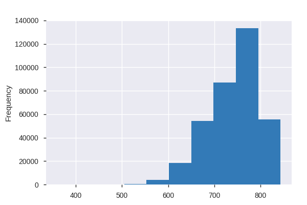

**Common Values**

| Value | Count | Frequency (%) |  |
| --- | --- | --- | --- |
| 790.0 | 3809 | 1.1% |  |
| 802.0 | 3650 | 1.0% |  |
| 801.0 | 3607 | 1.0% |  |
| 791.0 | 3604 | 1.0% |  |
| 797.0 | 3540 | 1.0% |  |
| 787.0 | 3403 | 1.0% |  |
| 780.0 | 3297 | 0.9% |  |
| 793.0 | 3292 | 0.9% |  |
| 798.0 | 3287 | 0.9% |  |
| 786.0 | 3263 | 0.9% |  |
| Other values (359) | 318036 | 90.0% |  |

**Extreme Values**

Minimum 5 values

| Value | Count | Frequency (%) |  |
| --- | --- | --- | --- |
| 360.0 | 1 | 0.0% |  |
| 380.0 | 1 | 0.0% |  |
| 400.0 | 1 | 0.0% |  |
| 426.0 | 1 | 0.0% |  |
| 431.0 | 1 | 0.0% |  |

Maximum 5 values

| Value | Count | Frequency (%) |  |
| --- | --- | --- | --- |
| 833.0 | 1 | 0.0% |  |
| 836.0 | 4 | 0.0% |  |
| 837.0 | 1 | 0.0% |  |
| 840.0 | 2 | 0.0% |  |
| 843.0 | 1 | 0.0% |  |

CO_BORROWER_CREDIT_SCORE  
Numeric

| Distinct count | 328 |
| --- | --- |
| Unique (%) | 0.1% |
| Missing (%) | 59.1% |
| Missing (n) | 208664 |
| Infinite (%) | 0.0% |
| Infinite (n) | 0 |

| Mean | 750.35 |
| --- | --- |
| Minimum | 433 |
| Maximum | 850 |
| Zeros (%) | 0.0% |

Toggle details

**Statistics**

Quantile statistics

| Minimum | 433 |
| --- | --- |
| 5-th percentile | 655 |
| Q1 | 719 |
| Median | 763 |
| Q3 | 790 |
| 95-th percentile | 809 |
| Maximum | 850 |
| Range | 417 |
| Interquartile range | 71 |

Descriptive statistics

| Standard deviation | 49.536 |
| --- | --- |
| Coef of variation | 0.066017 |
| Kurtosis | 0.38681 |
| Mean | 750.35 |
| MAD | 40.406 |
| Skewness | -0.92532 |
| Sum | 108510000 |
| Variance | 2453.8 |
| Memory size | 2.7 MiB |

**Histogram**

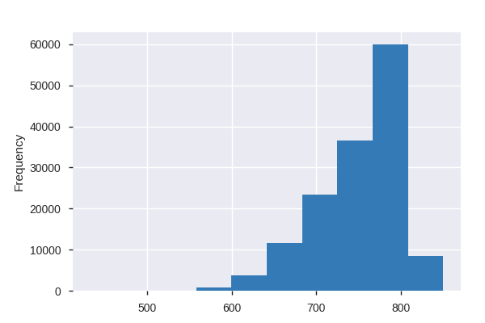

**Common Values**

| Value | Count | Frequency (%) |  |
| --- | --- | --- | --- |
| 801.0 | 1842 | 0.5% |  |
| 791.0 | 1815 | 0.5% |  |
| 797.0 | 1772 | 0.5% |  |
| 802.0 | 1749 | 0.5% |  |
| 790.0 | 1694 | 0.5% |  |
| 796.0 | 1677 | 0.5% |  |
| 787.0 | 1630 | 0.5% |  |
| 798.0 | 1610 | 0.5% |  |
| 809.0 | 1589 | 0.4% |  |
| 794.0 | 1533 | 0.4% |  |
| Other values (317) | 127702 | 36.1% |  |
| (Missing) | 208664 | 59.1% |  |

**Extreme Values**

Minimum 5 values

| Value | Count | Frequency (%) |  |
| --- | --- | --- | --- |
| 433.0 | 1 | 0.0% |  |
| 464.0 | 1 | 0.0% |  |
| 472.0 | 1 | 0.0% |  |
| 484.0 | 1 | 0.0% |  |
| 487.0 | 1 | 0.0% |  |

Maximum 5 values

| Value | Count | Frequency (%) |  |
| --- | --- | --- | --- |
| 836.0 | 1 | 0.0% |  |
| 837.0 | 1 | 0.0% |  |
| 839.0 | 2 | 0.0% |  |
| 843.0 | 1 | 0.0% |  |
| 850.0 | 2 | 0.0% |  |

DEBT_TO_INCOME_RATIO  
Numeric

| Distinct count | 65 |
| --- | --- |
| Unique (%) | 0.0% |
| Missing (%) | 3.2% |
| Missing (n) | 11339 |
| Infinite (%) | 0.0% |
| Infinite (n) | 0 |

| Mean | 38.092 |
| --- | --- |
| Minimum | 1 |
| Maximum | 64 |
| Zeros (%) | 0.0% |

Toggle details

**Statistics**

Quantile statistics

| Minimum | 1 |
| --- | --- |
| 5-th percentile | 17 |
| Q1 | 29 |
| Median | 38 |
| Q3 | 47 |
| 95-th percentile | 59 |
| Maximum | 64 |
| Range | 63 |
| Interquartile range | 18 |

Descriptive statistics

| Standard deviation | 12.482 |
| --- | --- |
| Coef of variation | 0.32769 |
| Kurtosis | -0.61174 |
| Mean | 38.092 |
| MAD | 10.297 |
| Skewness | -0.094817 |
| Sum | 13025000 |
| Variance | 155.81 |
| Memory size | 2.7 MiB |

**Histogram**

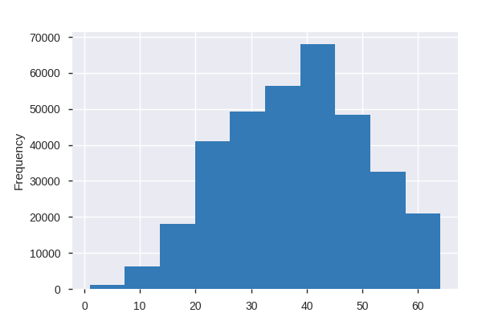

**Common Values**

| Value | Count | Frequency (%) |  |
| --- | --- | --- | --- |
| 43.0 | 9822 | 2.8% |  |
| 44.0 | 9786 | 2.8% |  |
| 42.0 | 9774 | 2.8% |  |
| 40.0 | 9763 | 2.8% |  |
| 39.0 | 9755 | 2.8% |  |
| 41.0 | 9657 | 2.7% |  |
| 38.0 | 9613 | 2.7% |  |
| 36.0 | 9499 | 2.7% |  |
| 37.0 | 9484 | 2.7% |  |
| 45.0 | 9404 | 2.7% |  |
| Other values (54) | 245381 | 69.5% |  |
| (Missing) | 11339 | 3.2% |  |

**Extreme Values**

Minimum 5 values

| Value | Count | Frequency (%) |  |
| --- | --- | --- | --- |
| 1.0 | 21 | 0.0% |  |
| 2.0 | 53 | 0.0% |  |
| 3.0 | 86 | 0.0% |  |
| 4.0 | 158 | 0.0% |  |
| 5.0 | 202 | 0.1% |  |

Maximum 5 values

| Value | Count | Frequency (%) |  |
| --- | --- | --- | --- |
| 60.0 | 3205 | 0.9% |  |
| 61.0 | 2811 | 0.8% |  |
| 62.0 | 2697 | 0.8% |  |
| 63.0 | 2732 | 0.8% |  |
| 64.0 | 2661 | 0.8% |  |

FIRST_PAYMENT_DATE  
Date

| Distinct count | 46 |
| --- | --- |
| Unique (%) | 0.0% |
| Missing (%) | 0.0% |
| Missing (n) | 0 |
| Infinite (%) | 0.0% |
| Infinite (n) | 0 |

| Minimum | 2001-11-01 00:00:00 |
| --- | --- |
| Maximum | 2008-11-01 00:00:00 |

Toggle details

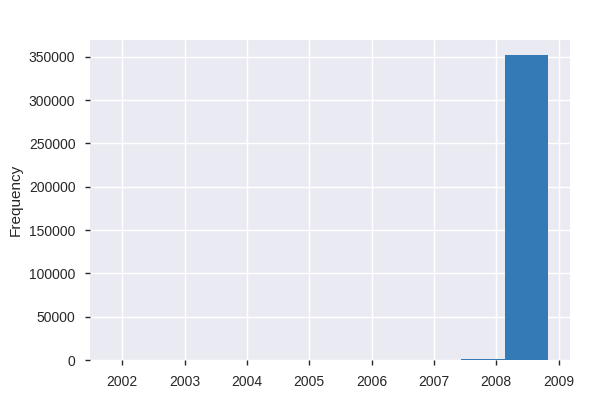

FIRST_TIME_HOME_BUYER_FLAG  
Categorical

| Distinct count | 3 |
| --- | --- |
| Unique (%) | 0.0% |
| Missing (%) | 0.0% |
| Missing (n) | 0 |

| N | 296739 |
| --- | --- |
| Y | 56284 |
| U | 254 |

Toggle details

| Value | Count | Frequency (%) |  |
| --- | --- | --- | --- |
| N | 296739 | 84.0% |  |
| Y | 56284 | 15.9% |  |
| U | 254 | 0.1% |  |

LOAN_ID  
Numeric

| Distinct count | 353277 |
| --- | --- |
| Unique (%) | 100.0% |
| Missing (%) | 0.0% |
| Missing (n) | 0 |
| Infinite (%) | 0.0% |
| Infinite (n) | 0 |

| Mean | 550580000000 |
| --- | --- |
| Minimum | 100003230356 |
| Maximum | 999999246774 |
| Zeros (%) | 0.0% |

Toggle details

**Statistics**

Quantile statistics

| Minimum | 100003230356 |
| --- | --- |
| 5-th percentile | 145090000000 |
| Q1 | 326110000000 |
| Median | 550350000000 |
| Q3 | 775310000000 |
| 95-th percentile | 955150000000 |
| Maximum | 999999246774 |
| Range | 899996016418 |
| Interquartile range | 449200000000 |

Descriptive statistics

| Standard deviation | 259670000000 |
| --- | --- |
| Coef of variation | 0.47163 |
| Kurtosis | -1.1988 |
| Mean | 550580000000 |
| MAD | 224860000000 |
| Skewness | -0.0016403 |
| Sum | 194505496702025812 |
| Variance | 6.7426e+22 |
| Memory size | 2.7 MiB |

**Histogram**

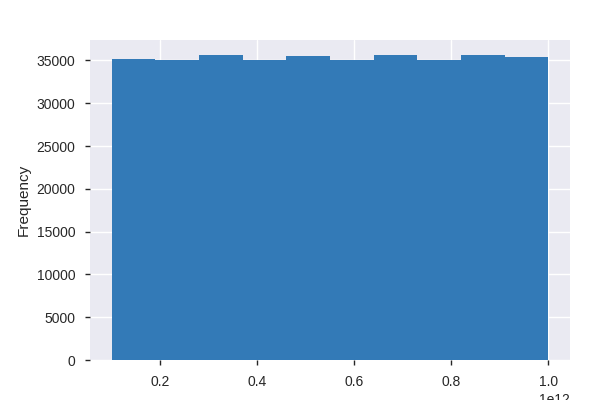

**Common Values**

| Value | Count | Frequency (%) |  |
| --- | --- | --- | --- |
| 579393953724 | 1 | 0.0% |  |
| 877992789938 | 1 | 0.0% |  |
| 628713511141 | 1 | 0.0% |  |
| 356171052043 | 1 | 0.0% |  |
| 476167079037 | 1 | 0.0% |  |
| 688341896767 | 1 | 0.0% |  |
| 544107320188 | 1 | 0.0% |  |
| 503167208476 | 1 | 0.0% |  |
| 410058943496 | 1 | 0.0% |  |
| 431280540186 | 1 | 0.0% |  |
| Other values (353267) | 353267 | 100.0% |  |

**Extreme Values**

Minimum 5 values

| Value | Count | Frequency (%) |  |
| --- | --- | --- | --- |
| 100003230356 | 1 | 0.0% |  |
| 100007366323 | 1 | 0.0% |  |
| 100008222989 | 1 | 0.0% |  |
| 100008959559 | 1 | 0.0% |  |
| 100010553836 | 1 | 0.0% |  |

Maximum 5 values

| Value | Count | Frequency (%) |  |
| --- | --- | --- | --- |
| 999995504903 | 1 | 0.0% |  |
| 999996916020 | 1 | 0.0% |  |
| 999998818599 | 1 | 0.0% |  |
| 999998855421 | 1 | 0.0% |  |
| 999999246774 | 1 | 0.0% |  |

LOAN_PURPOSE  
Categorical

| Distinct count | 3 |
| --- | --- |
| Unique (%) | 0.0% |
| Missing (%) | 0.0% |
| Missing (n) | 0 |

| P | 185936 |
| --- | --- |
| C | 106527 |
| R | 60814 |

Toggle details

| Value | Count | Frequency (%) |  |
| --- | --- | --- | --- |
| P | 185936 | 52.6% |  |
| C | 106527 | 30.2% |  |
| R | 60814 | 17.2% |  |

MORTGAGE_INSURANCE_PCT  
Numeric

| Distinct count | 20 |
| --- | --- |
| Unique (%) | 0.0% |
| Missing (%) | 78.7% |
| Missing (n) | 277888 |
| Infinite (%) | 0.0% |
| Infinite (n) | 0 |

| Mean | 23.337 |
| --- | --- |
| Minimum | 6 |
| Maximum | 40 |
| Zeros (%) | 0.0% |

Toggle details

**Statistics**

Quantile statistics

| Minimum | 6 |
| --- | --- |
| 5-th percentile | 12 |
| Q1 | 17 |
| Median | 25 |
| Q3 | 25 |
| 95-th percentile | 35 |
| Maximum | 40 |
| Range | 34 |
| Interquartile range | 8 |

Descriptive statistics

| Standard deviation | 6.8152 |
| --- | --- |
| Coef of variation | 0.29204 |
| Kurtosis | -0.55606 |
| Mean | 23.337 |
| MAD | 5.5248 |
| Skewness | -0.36791 |
| Sum | 1759300 |
| Variance | 46.447 |
| Memory size | 2.7 MiB |

**Histogram**

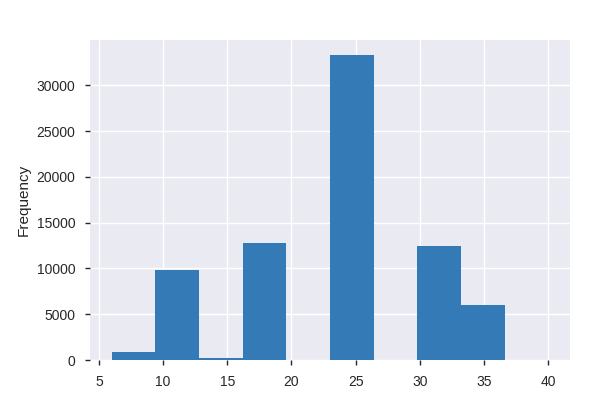

**Common Values**

| Value | Count | Frequency (%) |  |
| --- | --- | --- | --- |
| 25.0 | 33278 | 9.4% |  |
| 30.0 | 12447 | 3.5% |  |
| 17.0 | 12276 | 3.5% |  |
| 12.0 | 9824 | 2.8% |  |
| 35.0 | 5951 | 1.7% |  |
| 6.0 | 870 | 0.2% |  |
| 18.0 | 458 | 0.1% |  |
| 16.0 | 195 | 0.1% |  |
| 33.0 | 41 | 0.0% |  |
| 20.0 | 30 | 0.0% |  |
| Other values (9) | 19 | 0.0% |  |
| (Missing) | 277888 | 78.7% |  |

**Extreme Values**

Minimum 5 values

| Value | Count | Frequency (%) |  |
| --- | --- | --- | --- |
| 6.0 | 870 | 0.2% |  |
| 8.0 | 2 | 0.0% |  |
| 12.0 | 9824 | 2.8% |  |
| 15.0 | 1 | 0.0% |  |
| 16.0 | 195 | 0.1% |  |

Maximum 5 values

| Value | Count | Frequency (%) |  |
| --- | --- | --- | --- |
| 33.0 | 41 | 0.0% |  |
| 35.0 | 5951 | 1.7% |  |
| 36.0 | 2 | 0.0% |  |
| 39.0 | 2 | 0.0% |  |
| 40.0 | 4 | 0.0% |  |

MORTGAGE_INSURANCE_TYPE  
Numeric

| Distinct count | 3 |
| --- | --- |
| Unique (%) | 0.0% |
| Missing (%) | 78.7% |
| Missing (n) | 277888 |
| Infinite (%) | 0.0% |
| Infinite (n) | 0 |

| Mean | 1.1036 |
| --- | --- |
| Minimum | 1 |
| Maximum | 2 |
| Zeros (%) | 0.0% |

Toggle details

**Statistics**

Quantile statistics

| Minimum | 1 |
| --- | --- |
| 5-th percentile | 1 |
| Q1 | 1 |
| Median | 1 |
| Q3 | 1 |
| 95-th percentile | 2 |
| Maximum | 2 |
| Range | 1 |
| Interquartile range | 0 |

Descriptive statistics

| Standard deviation | 0.30472 |
| --- | --- |
| Coef of variation | 0.27612 |
| Kurtosis | 4.7701 |
| Mean | 1.1036 |
| MAD | 0.18571 |
| Skewness | 2.6019 |
| Sum | 83198 |
| Variance | 0.092855 |
| Memory size | 2.7 MiB |

**Histogram**

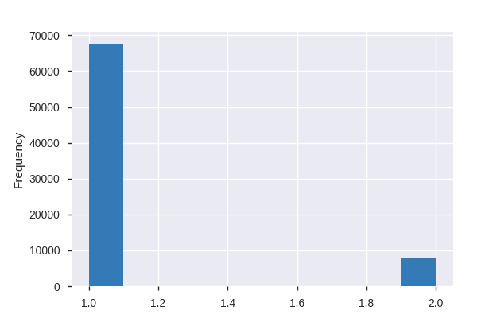

**Common Values**

| Value | Count | Frequency (%) |  |
| --- | --- | --- | --- |
| 1.0 | 67580 | 19.1% |  |
| 2.0 | 7809 | 2.2% |  |
| (Missing) | 277888 | 78.7% |  |

**Extreme Values**

Minimum 5 values

| Value | Count | Frequency (%) |  |
| --- | --- | --- | --- |
| 1.0 | 67580 | 19.1% |  |
| 2.0 | 7809 | 2.2% |  |

Maximum 5 values

| Value | Count | Frequency (%) |  |
| --- | --- | --- | --- |
| 1.0 | 67580 | 19.1% |  |
| 2.0 | 7809 | 2.2% |  |

NUM_OF_BORROWERS  
Numeric

| Distinct count | 7 |
| --- | --- |
| Unique (%) | 0.0% |
| Missing (%) | 0.0% |
| Missing (n) | 55 |
| Infinite (%) | 0.0% |
| Infinite (n) | 0 |

| Mean | 1.5131 |
| --- | --- |
| Minimum | 1 |
| Maximum | 6 |
| Zeros (%) | 0.0% |

Toggle details

**Statistics**

Quantile statistics

| Minimum | 1 |
| --- | --- |
| 5-th percentile | 1 |
| Q1 | 1 |
| Median | 2 |
| Q3 | 2 |
| 95-th percentile | 2 |
| Maximum | 6 |
| Range | 5 |
| Interquartile range | 1 |

Descriptive statistics

| Standard deviation | 0.51854 |
| --- | --- |
| Coef of variation | 0.34271 |
| Kurtosis | -0.95015 |
| Mean | 1.5131 |
| MAD | 0.50787 |
| Skewness | 0.22104 |
| Sum | 534450 |
| Variance | 0.26888 |
| Memory size | 2.7 MiB |

**Histogram**

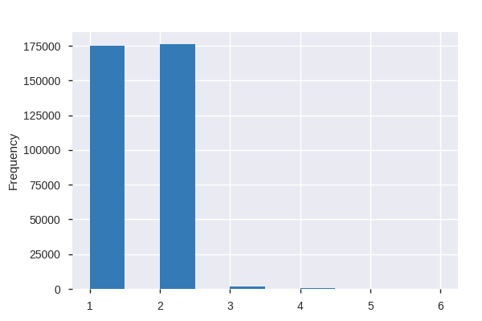

**Common Values**

| Value | Count | Frequency (%) |  |
| --- | --- | --- | --- |
| 2.0 | 176088 | 49.8% |  |
| 1.0 | 174825 | 49.5% |  |
| 3.0 | 1803 | 0.5% |  |
| 4.0 | 498 | 0.1% |  |
| 6.0 | 5 | 0.0% |  |
| 5.0 | 3 | 0.0% |  |
| (Missing) | 55 | 0.0% |  |

**Extreme Values**

Minimum 5 values

| Value | Count | Frequency (%) |  |
| --- | --- | --- | --- |
| 1.0 | 174825 | 49.5% |  |
| 2.0 | 176088 | 49.8% |  |
| 3.0 | 1803 | 0.5% |  |
| 4.0 | 498 | 0.1% |  |
| 5.0 | 3 | 0.0% |  |

Maximum 5 values

| Value | Count | Frequency (%) |  |
| --- | --- | --- | --- |
| 2.0 | 176088 | 49.8% |  |
| 3.0 | 1803 | 0.5% |  |
| 4.0 | 498 | 0.1% |  |
| 5.0 | 3 | 0.0% |  |
| 6.0 | 5 | 0.0% |  |

NUM_OF_UNITS  
Numeric

| Distinct count | 4 |
| --- | --- |
| Unique (%) | 0.0% |
| Missing (%) | 0.0% |
| Missing (n) | 0 |
| Infinite (%) | 0.0% |
| Infinite (n) | 0 |

| Mean | 1.0372 |
| --- | --- |
| Minimum | 1 |
| Maximum | 4 |
| Zeros (%) | 0.0% |

Toggle details

**Statistics**

Quantile statistics

| Minimum | 1 |
| --- | --- |
| 5-th percentile | 1 |
| Q1 | 1 |
| Median | 1 |
| Q3 | 1 |
| 95-th percentile | 1 |
| Maximum | 4 |
| Range | 3 |
| Interquartile range | 0 |

Descriptive statistics

| Standard deviation | 0.24429 |
| --- | --- |
| Coef of variation | 0.23553 |
| Kurtosis | 78.022 |
| Mean | 1.0372 |
| MAD | 0.072329 |
| Skewness | 8.1731 |
| Sum | 366423 |
| Variance | 0.059678 |
| Memory size | 2.7 MiB |

**Histogram**

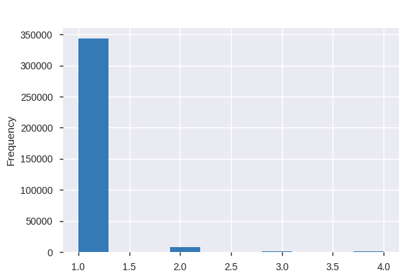

**Common Values**

| Value | Count | Frequency (%) |  |
| --- | --- | --- | --- |
| 1 | 343337 | 97.2% |  |
| 2 | 7741 | 2.2% |  |
| 3 | 1192 | 0.3% |  |
| 4 | 1007 | 0.3% |  |

**Extreme Values**

Minimum 5 values

| Value | Count | Frequency (%) |  |
| --- | --- | --- | --- |
| 1 | 343337 | 97.2% |  |
| 2 | 7741 | 2.2% |  |
| 3 | 1192 | 0.3% |  |
| 4 | 1007 | 0.3% |  |

Maximum 5 values

| Value | Count | Frequency (%) |  |
| --- | --- | --- | --- |
| 1 | 343337 | 97.2% |  |
| 2 | 7741 | 2.2% |  |
| 3 | 1192 | 0.3% |  |
| 4 | 1007 | 0.3% |  |

OCCUPANCY_STATUS  
Categorical

| Distinct count | 3 |
| --- | --- |
| Unique (%) | 0.0% |
| Missing (%) | 0.0% |
| Missing (n) | 0 |

| P | 296887 |
| --- | --- |
| I | 37104 |
| S | 19286 |

Toggle details

| Value | Count | Frequency (%) |  |
| --- | --- | --- | --- |
| P | 296887 | 84.0% |  |
| I | 37104 | 10.5% |  |
| S | 19286 | 5.5% |  |

ORIGINATION_CHANNEL  
Categorical

| Distinct count | 3 |
| --- | --- |
| Unique (%) | 0.0% |
| Missing (%) | 0.0% |
| Missing (n) | 0 |

| R | 136866 |
| --- | --- |
| C | 129702 |
| B | 86709 |

Toggle details

| Value | Count | Frequency (%) |  |
| --- | --- | --- | --- |
| R | 136866 | 38.7% |  |
| C | 129702 | 36.7% |  |
| B | 86709 | 24.5% |  |

ORIGINATION_DATE  
Date

| Distinct count | 47 |
| --- | --- |
| Unique (%) | 0.0% |
| Missing (%) | 0.0% |
| Missing (n) | 0 |
| Infinite (%) | 0.0% |
| Infinite (n) | 0 |

| Minimum | 2001-09-01 00:00:00 |
| --- | --- |
| Maximum | 2008-09-01 00:00:00 |

Toggle details

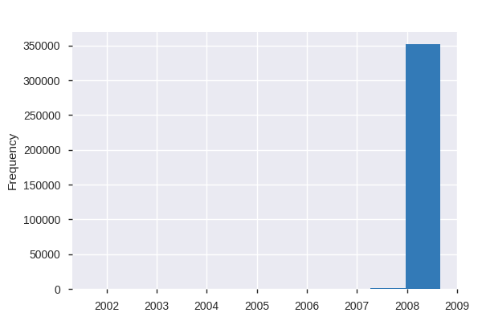

ORIG_COMBINED_LTV  
Highly correlated

*This variable is highly correlated with `ORIG_LTV` and should be ignored for analysis*

| Correlation | 0.96684 |
| --- | --- |

ORIG_INTEREST_RATE  
Numeric

| Distinct count | 487 |
| --- | --- |
| Unique (%) | 0.1% |
| Missing (%) | 0.0% |
| Missing (n) | 0 |
| Infinite (%) | 0.0% |
| Infinite (n) | 0 |

| Mean | 6.2966 |
| --- | --- |
| Minimum | 4 |
| Maximum | 9.75 |
| Zeros (%) | 0.0% |

Toggle details

**Statistics**

Quantile statistics

| Minimum | 4 |
| --- | --- |
| 5-th percentile | 5.5 |
| Q1 | 5.99 |
| Median | 6.375 |
| Q3 | 6.625 |
| 95-th percentile | 7.125 |
| Maximum | 9.75 |
| Range | 5.75 |
| Interquartile range | 0.635 |

Descriptive statistics

| Standard deviation | 0.48403 |
| --- | --- |
| Coef of variation | 0.076872 |
| Kurtosis | 0.24608 |
| Mean | 6.2966 |
| MAD | 0.38327 |
| Skewness | 0.032221 |
| Sum | 2224400 |
| Variance | 0.23428 |
| Memory size | 2.7 MiB |

**Histogram**

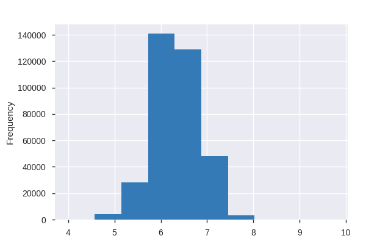

**Common Values**

| Value | Count | Frequency (%) |  |
| --- | --- | --- | --- |
| 6.375 | 47738 | 13.5% |  |
| 5.875 | 39210 | 11.1% |  |
| 6.5 | 38278 | 10.8% |  |
| 6.25 | 33645 | 9.5% |  |
| 6.0 | 26140 | 7.4% |  |
| 6.875 | 22190 | 6.3% |  |
| 6.75 | 21980 | 6.2% |  |
| 6.125 | 21529 | 6.1% |  |
| 6.625 | 19749 | 5.6% |  |
| 5.75 | 16437 | 4.7% |  |
| Other values (477) | 66381 | 18.8% |  |

**Extreme Values**

Minimum 5 values

| Value | Count | Frequency (%) |  |
| --- | --- | --- | --- |
| 4.0 | 8 | 0.0% |  |
| 4.25 | 8 | 0.0% |  |
| 4.375 | 24 | 0.0% |  |
| 4.5 | 47 | 0.0% |  |
| 4.625 | 135 | 0.0% |  |

Maximum 5 values

| Value | Count | Frequency (%) |  |
| --- | --- | --- | --- |
| 8.625 | 5 | 0.0% |  |
| 8.75 | 6 | 0.0% |  |
| 8.875 | 3 | 0.0% |  |
| 9.125 | 2 | 0.0% |  |
| 9.75 | 1 | 0.0% |  |

ORIG_LOAN_TERM  
Numeric

| Distinct count | 116 |
| --- | --- |
| Unique (%) | 0.0% |
| Missing (%) | 0.0% |
| Missing (n) | 0 |
| Infinite (%) | 0.0% |
| Infinite (n) | 0 |

| Mean | 328.41 |
| --- | --- |
| Minimum | 60 |
| Maximum | 360 |
| Zeros (%) | 0.0% |

Toggle details

**Statistics**

Quantile statistics

| Minimum | 60 |
| --- | --- |
| 5-th percentile | 180 |
| Q1 | 360 |
| Median | 360 |
| Q3 | 360 |
| 95-th percentile | 360 |
| Maximum | 360 |
| Range | 300 |
| Interquartile range | 0 |

Descriptive statistics

| Standard deviation | 68.129 |
| --- | --- |
| Coef of variation | 0.20745 |
| Kurtosis | 1.3877 |
| Mean | 328.41 |
| MAD | 51.535 |
| Skewness | -1.7838 |
| Sum | 116018474 |
| Variance | 4641.6 |
| Memory size | 2.7 MiB |

**Histogram**

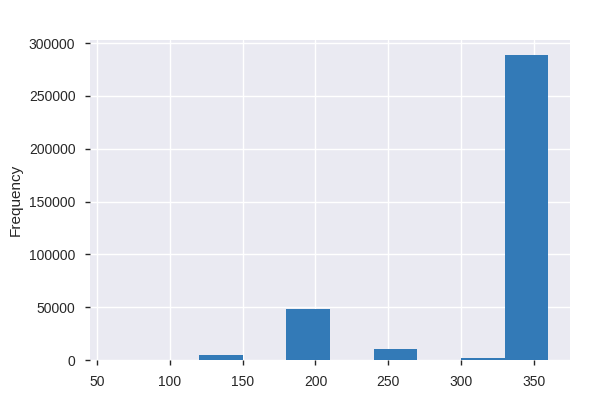

**Common Values**

| Value | Count | Frequency (%) |  |
| --- | --- | --- | --- |
| 360 | 287367 | 81.3% |  |
| 180 | 48239 | 13.7% |  |
| 240 | 9931 | 2.8% |  |
| 120 | 4674 | 1.3% |  |
| 300 | 1448 | 0.4% |  |
| 351 | 139 | 0.0% |  |
| 352 | 129 | 0.0% |  |
| 353 | 120 | 0.0% |  |
| 354 | 108 | 0.0% |  |
| 348 | 96 | 0.0% |  |
| Other values (106) | 1026 | 0.3% |  |

**Extreme Values**

Minimum 5 values

| Value | Count | Frequency (%) |  |
| --- | --- | --- | --- |
| 60 | 6 | 0.0% |  |
| 72 | 1 | 0.0% |  |
| 84 | 5 | 0.0% |  |
| 96 | 19 | 0.0% |  |
| 108 | 3 | 0.0% |  |

Maximum 5 values

| Value | Count | Frequency (%) |  |
| --- | --- | --- | --- |
| 356 | 47 | 0.0% |  |
| 357 | 24 | 0.0% |  |
| 358 | 17 | 0.0% |  |
| 359 | 2 | 0.0% |  |
| 360 | 287367 | 81.3% |  |

ORIG_LTV  
Numeric

| Distinct count | 97 |
| --- | --- |
| Unique (%) | 0.0% |
| Missing (%) | 0.0% |
| Missing (n) | 0 |
| Infinite (%) | 0.0% |
| Infinite (n) | 0 |

| Mean | 72.422 |
| --- | --- |
| Minimum | 1 |
| Maximum | 97 |
| Zeros (%) | 0.0% |

Toggle details

**Statistics**

Quantile statistics

| Minimum | 1 |
| --- | --- |
| 5-th percentile | 37 |
| Q1 | 64 |
| Median | 79 |
| Q3 | 80 |
| 95-th percentile | 95 |
| Maximum | 97 |
| Range | 96 |
| Interquartile range | 16 |

Descriptive statistics

| Standard deviation | 17.052 |
| --- | --- |
| Coef of variation | 0.23545 |
| Kurtosis | 0.82763 |
| Mean | 72.422 |
| MAD | 13.259 |
| Skewness | -1.0582 |
| Sum | 25584913 |
| Variance | 290.77 |
| Memory size | 2.7 MiB |

**Histogram**

[5 more figures not shown]

Sample

|  | LOAN_ID | ORIGINATION_CHANNEL | SELLER_NAME | ORIG_INTEREST_RATE | ORIG_UNPAID_PRINCIPAL_BALANCE | ORIG_LOAN_TERM | ORIGINATION_DATE | FIRST_PAYMENT_DATE | ORIG_LTV | ORIG_COMBINED_LTV | NUM_OF_BORROWERS | DEBT_TO_INCOME_RATIO | BORROWER_CREDIT_SCORE | FIRST_TIME_HOME_BUYER_FLAG | LOAN_PURPOSE | PROPERTY_TYPE | NUM_OF_UNITS | OCCUPANCY_STATUS | PROPERTY_STATE | ZIP3 | MORTGAGE_INSURANCE_PCT | PRODUCT_TYPE | CO_BORROWER_CREDIT_SCORE | MORTGAGE_INSURANCE_TYPE | RELOCATION_MORTGAGE_FLAG | BAD_LOAN |
| --- | --- | --- | --- | --- | --- | --- | --- | --- | --- | --- | --- | --- | --- | --- | --- | --- | --- | --- | --- | --- | --- | --- | --- | --- | --- | --- |
| 0 | 100003230356 | B | WELLS FARGO BANK, N.A. | 6.625 | 338000 | 360 | 2008-08-01 | 2008-10-01 | 90 | 90.0 | 2.0 | 46.0 | 647.0 | N | P | PU | 1 | P | FL | 342 | 25.0 | FRM | 647.0 | 1.0 | N | 0 |
| 1 | 100007366323 | R | WELLS FARGO BANK, N.A. | 6.125 | 440000 | 360 | 2008-07-01 | 2008-09-01 | 80 | 80.0 | 2.0 | 32.0 | 723.0 | N | P | PU | 1 | P | VA | 201 | NaN | FRM | 723.0 | NaN | N | 0 |
| 2 | 100008222989 | C | GMAC MORTGAGE, LLC | 6.375 | 69000 | 240 | 2008-06-01 | 2008-07-01 | 83 | 83.0 | 2.0 | 24.0 | 709.0 | N | C | SF | 1 | P | MS | 387 | 6.0 | FRM | 688.0 | 1.0 | N | 0 |
| 3 | 100008959559 | R | GMAC MORTGAGE, LLC | 6.875 | 100000 | 360 | 2008-06-01 | 2008-08-01 | 80 | 80.0 | 1.0 | 39.0 | 691.0 | N | C | SF | 1 | P | SD | 570 | NaN | FRM | NaN | NaN | N | 1 |
| 4 | 100010553836 | C | WELLS FARGO BANK, N.A. | 5.875 | 128000 | 360 | 2008-06-01 | 2008-08-01 | 47 | 47.0 | 2.0 | 22.0 | 785.0 | N | P | SF | 1 | P | TX | 799 | NaN | FRM | 785.0 | NaN | N | 0 |

```python
pandas_profiling.ProfileReport(df)
#profile = pandas_profiling.ProfileReport(df)
```

# Visual data exploration

### Bad loans (traget variable)

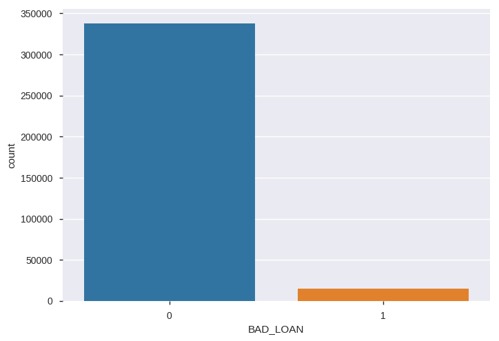

```python
sns.countplot(df['BAD_LOAN'])
```

The figures below show boxplots for several columns in our dataset. Boxplots are assembled such that 25% of the data values are contained between the lowest whisker and the bottom of the box, 50% of the values are contained within the box itself, and 25% of the values are spanned between the top of the box and the top whisker. The median value of the data is represented by the horizontal line in the middle of each box.

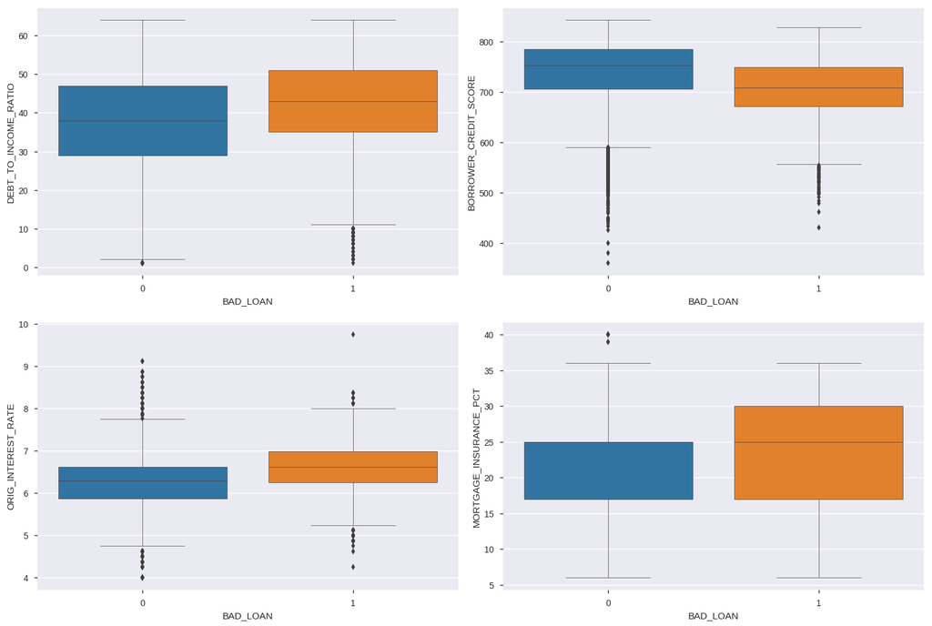

```python
columns = ['DEBT_TO_INCOME_RATIO','BORROWER_CREDIT_SCORE', 'ORIG_INTEREST_RATE','MORTGAGE_INSURANCE_PCT']

fig, axes = mp.subplots(nrows=2, ncols=2, figsize=(15,10))
mp.tight_layout(w_pad=2.0, h_pad=3.0)

for i, column in zip(range(1,5), columns):
    mp.subplot(2,2,i)
    sns.boxplot(x="BAD_LOAN", y=column, data=df, linewidth=0.5)
    mp.xlabel('BAD_LOAN')
```

The figures show that on average, bad loans have:

```
 higher debt-to-income ratio
 lower credit scores
 higher interest rates
 higher mortgatge insurance percentage
```

### Debt to income ratio

```
Text(0,0.5,'DEBT TO INCOME RATIO')
```

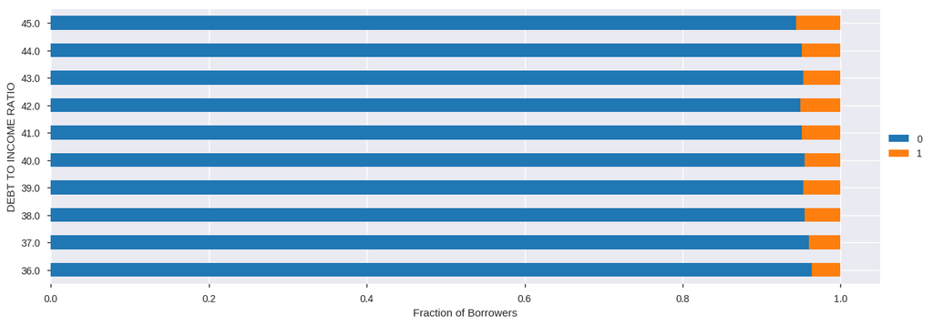

```python
top_10_DTIR = df.loc[df['DEBT_TO_INCOME_RATIO'].isin(df['DEBT_TO_INCOME_RATIO'].value_counts().index.tolist()[:10])]
dtir_pivot = pd.pivot_table(top_10_DTIR, index='DEBT_TO_INCOME_RATIO', columns='BAD_LOAN', aggfunc='size')
dtir_frac = dtir_pivot.div(dtir_pivot.sum(axis=1),# sum of bad loan 0 and 1
                           axis=0)

dtir_frac.plot.barh(stacked=True, figsize=(15,5))

mp.legend(loc='center left', bbox_to_anchor=(1.0, 0.5))
mp.xlabel('Fraction of Borrowers')
mp.ylabel('DEBT TO INCOME RATIO')
```

### ZIP code 3 digits

```
Text(0,0.5,'ZIP Code')
```

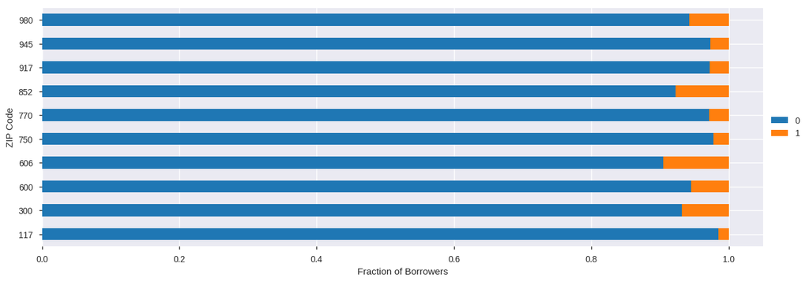

```python
top_10_zip = df.loc[df['ZIP3'].isin(df['ZIP3'].value_counts().index.tolist()[:10])]
zip_pivot = pd.pivot_table(top_10_zip, index='ZIP3', columns='BAD_LOAN', aggfunc='size')
zip_frac = zip_pivot.div(zip_pivot.sum(axis=1),# sum of bad loan 0 and 1
              axis=0)

zip_frac.plot.barh(stacked=True, figsize=(15,5))

mp.legend(loc='center left', bbox_to_anchor=(1.0, 0.5))
mp.xlabel('Fraction of Borrowers')
mp.ylabel('ZIP Code')
```

Looking at the above chart it is evident that ZIP code can be a indicator of bad loans. For example, borrowers belonging to zip codes 606 have more bad loans compared to zip code ending 117.

## Data pre processing

**Removing some variables based on profiling report**

According to profiling data, our dataset has `353277` rows and `27` columns.

The columns containing missing data are:

```
CO_BORROWER_CREDIT_SCORE has 208664 (59.1%) missing values
DEBT_TO_INCOME_RATIO has 11339 (3.2%) missing values
MORTGAGE_INSURANCE_PCT has 277888 (78.7%) missing values
MORTGAGE_INSURANCE_TYPE has 277888 (78.7%) missing values
ORIG_COMBINED_LTV has 2 (<1 %)  missing values
NUM_OF_BORROWERS has 55 (<1 %)  missing values
BORROWER_CREDIT_SCORE has 489 (<1 %)  missing values
```

The columns which should be removed are:

```
ORIG_COMBINED_LTV is highly correlated with ORIG_LTV (ρ = 0.96684)
PRODUCT_TYPE has constant value FRM
```

Based on above info, we will delete folloing columns from our dataset

```
MORTGAGE_INSURANCE_PCT
MORTGAGE_INSURANCE_TYPE
CO_BORROWER_CREDIT_SCORE
ORIG_COMBINED_LTV
PRODUCT_TYPE
```

Additionally, `LOAN_ID` column doesn't contribute to outcome of loan so it also be removed

```python
df.drop(['LOAN_ID', 'MORTGAGE_INSURANCE_PCT','MORTGAGE_INSURANCE_TYPE', 'CO_BORROWER_CREDIT_SCORE',
         'ORIG_COMBINED_LTV','PRODUCT_TYPE'], axis=1, inplace=True)
```

**Extract mont and year from dates**

```python
df['ORIGINATION_MONTH'] = df['ORIGINATION_DATE'].apply(lambda x : x.date().month)
df['ORIGINATION_YEAR'] = df['ORIGINATION_DATE'].apply(lambda x : x.date().year)

df['FIRST_PAYMENT_MONTH'] = df['FIRST_PAYMENT_DATE'].apply(lambda x : x.date().month)
df['FIRST_PAYMENT_YEAR'] = df['FIRST_PAYMENT_DATE'].apply(lambda x : x.date().year)

df.drop(['ORIGINATION_DATE','FIRST_PAYMENT_DATE'], axis=1, inplace=True)
```

**Convert categorigal variables into new variables**

We are using this helper function to get new variables for the categorical columns.

```python
def process_categorical_cols(df):
    #names of columns with any nan values
    cols_with_nans = df.columns[df.isnull().any()]
    #make a copy of these columns
    df_with_nans = df[cols_with_nans]
    # drop these columns from processing
    df.drop(cols_with_nans, axis=1, inplace=True)

    # get categorical columns by filtering based on columns of type object i.e string values
    df_cat = df.select_dtypes(include=['object'])
    # get numerical columns (by dropping categorical columns)
    df_num = df.drop(df_cat.columns, axis=1)

    data = pd.DataFrame()
    for i in df_cat.columns:
        tmp = pd.get_dummies(df_cat[i], drop_first=True)
        data = pd.concat([data, tmp], axis=1)

    # create a new dataframe containing numerical columns, converted categoricals and columns which has nans
    df = pd.concat([df_num, data, df_with_nans], axis=1).reset_index(drop=True)
    return df
```

```python
df = process_categorical_cols(df)
```

### Impute missing values

We have following options to fix missing values:

```
1. Mean/Median based on distribution of data
2. Random sample from a distribution defined by the present values.
3. Machine learning algorithm applied to the create values
4. Drop the missing data rows altogether.
```

Lets find fields which have missing values

```python
df_len = len(df)
df_missing = pd.DataFrame({"Missing" : df.apply(lambda x: x.isnull().sum(), axis=0)})
df_missing["Missing Pct"] = df_missing.Missing.apply(lambda x: x*1.0/df_len)
df_missing.loc[df_missing.Missing > 0 ]
#pd.DataFrame({"missing_count": profile.description_set['variables']['n_missing'] }).reset_index()
```

|  | Missing | Missing Pct |
| --- | --- | --- |
| NUM_OF_BORROWERS | 55 | 0.000156 |
| DEBT_TO_INCOME_RATIO | 11339 | 0.032097 |
| BORROWER_CREDIT_SCORE | 489 | 0.001384 |

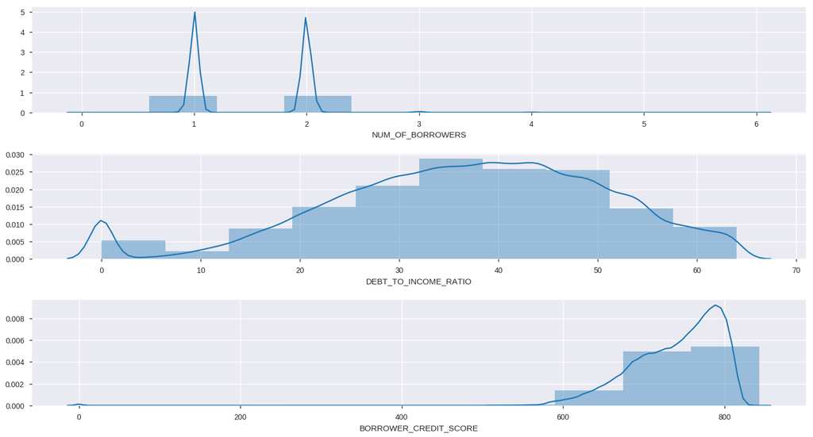

```python
columns = ['NUM_OF_BORROWERS','DEBT_TO_INCOME_RATIO','BORROWER_CREDIT_SCORE']

fig, axes = mp.subplots(nrows=3, ncols=1, figsize=(15,8))
mp.tight_layout(w_pad=2.0, h_pad=3.0)

for i, column in zip(range(1,5), columns):
    mp.subplot(3,1,i)
    sns.distplot(df[column].fillna(0) , bins=10)
```

Fill the missing values using:

```
A random forest classifier for strings - A random forest is a meta estimator that fits a number of decision tree classifiers on various sub-samples of the dataset and use averaging to improve the predictive accuracy and control over-fitting. The sub-sample size is always the same as the original input sample size but the samples are drawn with replacement.

A random forest regressor for numerical columns - A random forest is a meta estimator that fits a number of classifying decision trees on various sub-samples of the dataset and use averaging to improve the predictive accuracy and control over-fitting. The sub-sample size is always the same as the original input sample size but the samples are drawn with replacement.
```

```python
def imputer(df):
    # columns which have missing values
    columns = df.columns[df.isnull().any()]
    # loop over columns with missing values
    for name in columns:
        # get non null values of this column
        y = df.loc[df[name].notnull(), name].values
        # data having no nulls - used for training
        X_train = df.loc[df[name].notnull()].drop(columns, axis=1).values
        # data having nulls - used for testing
        X_test = df.loc[df[name].isnull()].drop(columns, axis=1).values

        if df[name].dtypes == 'object':
            model = RandomForestClassifier(n_estimators=400, max_depth=3)
            model.fit(X_train, y)
            # impute values by predicting them
            df.loc[df[name].isnull(), name] = model.predict(X_test)
        else:
            model = RandomForestRegressor(n_estimators=400, max_depth=3)
            model.fit(X_train, y)
            #impute values by predicting them
            df.loc[df[name].isnull(), name] = model.predict(X_test)
    return df
```

```python
df = imputer(df)
```

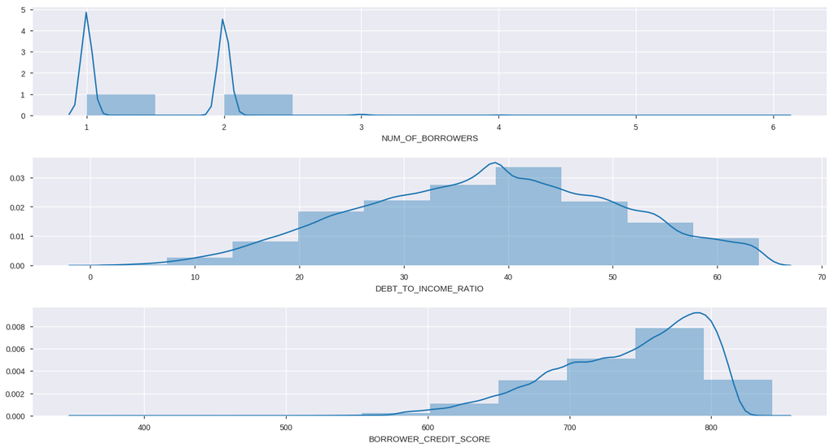

```python
columns = ['NUM_OF_BORROWERS','DEBT_TO_INCOME_RATIO','BORROWER_CREDIT_SCORE']

fig, axes = mp.subplots(nrows=3, ncols=1, figsize=(15,8))
mp.tight_layout(w_pad=2.0, h_pad=3.0)

for i, column in zip(range(1,5), columns):
    mp.subplot(3,1,i)
    sns.distplot(df[column].fillna(0) , bins=10)
```

## Balancing proportion of target variable

As identified earlier, the the proportion of two values of target variable `BAD_LOAN` is extremely imbalanced. The bad loan make up for `<5%` of all borrowers. In such a case, the machine learning algorithm will be biased towards predicting the dominant class. To balance the propostion of good/bad loans, lets use `Synthetic Minority Oversampling Technique (SMOTE)`.

```python
from imblearn.combine import SMOTEENN
sm = SMOTEENN()

y = df['BAD_LOAN'].values
X = df.drop(['BAD_LOAN'], axis=1).values

X_resampled, y_resampled = sm.fit_sample(X, y)
```